# Wdh: Einfache lineare Regression

Autor:in

Zugehörigkeit

Samuel Merk

Pädagogische Hochschule Karlsruhe

Die einfache lineare Regression ist ein sehr grundlegendes statistisches Modell: Einerseits können mit ihr sehr viele deskriptive, explorative und explanative Forschungsfragen beantwortet werden, andererseits ist sie die Grundlage für komplexere Modellierungen wie Strukturgleichungs- oder Mehrebenenmodelle. Daher ist es wichtig, die Grundlagen der einfachen linearen Regression zu verstehen.

## 1 Grundidee

Die einfache lineare Regression modelliert die Beziehung zwischen einer »abhängigen Variable« $y$ (auch »Outcome«, »Response«, »Regressant«) und einer »unabhängigen Variable« $x$ (auch »Prädiktor«, »Regressor«) linear (und damit monoton siehe Abbildung 1).

[figure not shown]

Abbildung 1: Visualisierung (nicht-)monotoner und (nicht-)linearer Funktionen

Dabei werden zunächst keine Annahmen über die Verteilungen von $y$ und $x$ gemacht - beide Variablen sollten jedoch intervallskaliert interpretierbar sein (siehe Abbildung 2):

[figure not shown]

Abbildung 2: Regression mit unterschiedlichen Verteilungen in $x$ und $y$

## 2 Geometrische Repräsentation

Jedes Modell einer einfachen linearen Regression ist durch die Annahme der Linearität und die Festlegung eines Punktes und einer Steigung (oder zweier Punkte) eindeutig bestimmt. Für vorliegende Datenreihen von $x$ und $y$ wird die Regressiongerade meist so bestimmt, dass die Summe der Residuenquadrate möglichst klein wird:

Regressionsgerade Intercept Slope Residuen Quadrierte Residuen

[interactive chart not shown]

Fügen Sie Punkte hinzu

### Übung

Erzeugen Sie in der interaktiven Visualisierung genau vier Punkte und zwar (3;1), (3;2), (4;1), (4;2).

- Das Intercept $b_0$ der dadurch entstehenden Regressionsgerade beträgt dann .
- Warum zeigt diesen Beispiel, dass das ebenfalls naheliegende Optimierungkriterium der Summe der kleinsten Residualbeträge $\sum_{i=1}^{N} \left| \varepsilon_i \right|$ problematisch wäre?

Es lässt sich beweisen, dass die Regressionsgerade - bestimmt durch die Summe der kleinsten Quadrate - immer den »Schwerpunkt« der Punktewolke $\left(\bar{x}; \bar{y}\right)$ enthält. Da die Punkte ein Rechteck mit Kanten parallel zu den Koordinatenachsen darstellen, ist $b_1 = 0$ und daher $b_0 = \bar{y}$.

Wäre das Optimierungskriterium für $b_0$ und $b_1$ die Summe der Residuenbeträge $\sum_{i=1}^{N} \left| \varepsilon_i \right|$ wäre jede Regressionsgerade mit $b_1 = 0$ und $min(x_i) < b_0 < max(x_i)$ »gleich optimal« - die Regressionsgerade wäre also nicht eindeutig bestimmt.

### Übung

Erzeugen Sie in der interaktiven Visualisierung genau vier Punkte und zwar (-1;0), (-1;3), (2;0), (2;3).

- Das Intercept $b_0$ der dadurch entstehenden Regressionsgerade beträgt dann .
- Warum zeigt diesen Beispiel, dass das ebenfalls naheliegende Optimierungkriterium der Summe der kleinsten Residualbeträge $\sum_{i=1}^{N} \left| \varepsilon_i \right|$ problematisch wäre?

Es lässt sich beweisen, dass die Regressionsgerade - bestimmt durch die Summe der kleinsten Quadrate - immer den »Schwerpunkt« der Punktewolke $\left(\bar{x}; \bar{y}\right)$ enthält. Da die Punkte ein Rechteck mit Kanten parallel zu den Koordinatenachsen darstellen, ist $b_1 = 0$ und daher $b_0 = \bar{y}$.

Wäre das Optimierungskriterium für $b_0$ und $b_1$ die Summe der Residuenbeträge $\sum_{i=1}^{N} \left| \varepsilon_i \right|$ wäre jede Regressionsgerade mit $b_1 = 0$ und $min(x_i) < b_0 < max(x_i)$ »gleich optimal« - die Regressionsgerade wäre also nicht eindeutig bestimmt.

### Übung

Erzeugen Sie in der interaktiven Visualisierung genau vier Punkte und zwar (-3;-2), (-3;3), (1;-2), (1;3).

- Das Intercept $b_0$ der dadurch entstehenden Regressionsgerade beträgt dann .
- Warum zeigt diesen Beispiel, dass das ebenfalls naheliegende Optimierungkriterium der Summe der kleinsten Residualbeträge $\sum_{i=1}^{N} \left| \varepsilon_i \right|$ problematisch wäre?

Es lässt sich beweisen, dass die Regressionsgerade - bestimmt durch die Summe der kleinsten Quadrate - immer den »Schwerpunkt« der Punktewolke $\left(\bar{x}; \bar{y}\right)$ enthält. Da die Punkte ein Rechteck mit Kanten parallel zu den Koordinatenachsen darstellen, ist $b_1 = 0$ und daher $b_0 = \bar{y}$.

Wäre das Optimierungskriterium für $b_0$ und $b_1$ die Summe der Residuenbeträge $\sum_{i=1}^{N} \left| \varepsilon_i \right|$ wäre jede Regressionsgerade mit $b_1 = 0$ und $min(x_i) < b_0 < max(x_i)$ »gleich optimal« - die Regressionsgerade wäre also nicht eindeutig bestimmt.

## 3 Algebraische Notation

[figure not shown]

Abbildung 3: Begriffe in der algebraischen Notation

Um diese geometrische Repräsentation algebraisch zu notieren, müssen die folgenden Begriffe definiert werden (siehe auch Abbildung 3)

- $_i$ – **Index** für die Beobachtungen (1 bis n). Damit sind z.B. $x_i$ und $y_i$ sind die Werte der unabhängigen und abhängigen Variable für die i-te Beobachtung.
- $\hat{y}_i$ – Durch die Regression **vorhergesagter Wert** der abhängigen Variable für die i-te Beobachtung. Der Punkt $\left(x_i, \hat{y}_i\right)$ liegt immer auf der Regressionsgeraden.
- $\epsilon_i$ – **Residuum** der i-ten Beobachtung. Das Residuum ist die Differenz zwischen dem beobachteten Wert $y_i$ und dem durch das Modell vorhergesagten Wert $\hat{y}_i$.
- $b_0$ – **Achsenabschnitt** der Regressionsgeraden. Er ist der vorhergesagte Wert der abhängigen Variable, wenn die unabhängige Variable den Wert 0 annimmt.
- $b_1$ – **Steigung** der Regressionsgeraden. Sie gibt an, um wie viele Einheiten sich die abhängige Variable im Durchschnitt unterscheidet, wenn sich die unabhängige Variable um eine Einheit unterscheidet.

Die Beziehungen dieser Begriffe kann dann wie folgt notiert werden:

$$y_i = b_0 + b_1 \cdot x_i + \varepsilon_i
\tag{1}$$

$$\hat{y}_i = b_0 + b_1 \cdot x_i
\tag{2}$$

Setzt man nun Gleichung 2 in Gleichung 1 ein, so erhält man:

$$y_i = \hat{y}_i + \varepsilon_i \Leftrightarrow
\tag{3}$$

$$y_i - \varepsilon_i= \hat{y}_i$$

wonach der beobachtete Wert $y_i$ als Summe des durch das Modell vorhergesagten Wertes $\hat{y}_i$ und dem Residuum $\varepsilon_i$ dargestellt werden kann (siehe Abbildung 3).

### Übung

Welche der Begriffe passen zum grün hervorgehobenen Teil der folgenden Abbildung?

[figure not shown]

ResiduumVorhergesagtes yᵢInterceptGibt an, um wie viel sich y im Durchschnitt unterscheidet, wenn x sich um eine Einheit unterscheidet.Slope

### Übung

Welche der Begriffe passen zum grün hervorgehobenen Teil der folgenden Abbildung?

[figure not shown]

x-WertAusprägung der unabhängigen VariableErrorAusprägung der abhängigen Variable, die durch das Modell für xᵢ vorhergesagt wird.Vorhergesagtes yᵢ

### Übung

Welche der Begriffe passen zum grün hervorgehobenen Teil der folgenden Abbildung?

[figure not shown]

Predicted yᵢErrorAnstiegb₀ε

### Übung

Welche der Begriffe passen zum grün hervorgehobenen Teil der folgenden Abbildung?

[figure not shown]

Ausprägung der abhängigen Variableεb₀Vorhergesagtes yᵢAusprägung der abhängigen Variable, die durch das Modell für xᵢ vorhergesagt wird.

### Übung

Welche der Begriffe passen zum grün hervorgehobenen Teil der folgenden Abbildung?

[figure not shown]

ResiduumWert von ŷ, wenn x gleich 0 ist.b₀Achsenabschnittŷᵢ

### Übung

Welche der Begriffe passen zum grün hervorgehobenen Teil der folgenden Abbildung?

[figure not shown]

SteigungyᵢAusprägung der unabhängigen VariableAusprägung der abhängigen VariableVorhergesagtes yᵢ

### Übung

Welche der Begriffe passen zum grün hervorgehobenen Teil der folgenden Abbildung?

[figure not shown]

Ausprägung der unabhängigen VariableWert von ŷ, wenn x gleich 0 ist.Gibt an, um wie viel sich y im Durchschnitt unterscheidet, wenn x sich um eine Einheit unterscheidet.x-Wertŷᵢ

### Übung

Welche der Begriffe passen zum grün hervorgehobenen Teil der folgenden Abbildung?

[figure not shown]

ResiduumWert von ŷ, wenn x gleich 0 ist.Ausprägung der abhängigen Variable, die durch das Modell für xᵢ vorhergesagt wird.xᵢŷᵢ

### Übung

Welche der Begriffe passen zum grün hervorgehobenen Teil der folgenden Abbildung?

[figure not shown]

xᵢAusprägung der abhängigen Variable, die durch das Modell für xᵢ vorhergesagt wird.ResiduumErrorAnstieg

### Übung

Welche der Begriffe passen zum grün hervorgehobenen Teil der folgenden Abbildung?

[figure not shown]

Differenz zwischen beobachtetem und vorhergesagtem Wert.SteigungεPredicted yᵢy-Wert

### Übung

Welche der Begriffe passen zum grün hervorgehobenen Teil der folgenden Abbildung?

[figure not shown]

ErrorAnstiegGibt an, um wie viel sich y im Durchschnitt unterscheidet, wenn x sich um eine Einheit unterscheidet.x-WertAusprägung der abhängigen Variable, die durch das Modell für xᵢ vorhergesagt wird.

### Übung

Welche der Begriffe passen zum grün hervorgehobenen Teil der folgenden Abbildung?

[figure not shown]

ResiduumErrorAnstiegAusprägung der unabhängigen Variableb₀

### Übung

Welche der Begriffe passen zum grün hervorgehobenen Teil der folgenden Abbildung?

[figure not shown]

yᵢAusprägung der unabhängigen Variablex-WertDifferenz zwischen beobachtetem und vorhergesagtem Wert.Residuum

### Übung

Welche der Begriffe passen zum grün hervorgehobenen Teil der folgenden Abbildung?

[figure not shown]

ŷᵢWert von ŷ, wenn x gleich 0 ist.b₀Interceptx-Wert

### Übung

Welche der Begriffe passen zum grün hervorgehobenen Teil der folgenden Abbildung?

[figure not shown]

b₁Ausprägung der unabhängigen VariableAusprägung der abhängigen Variable, die durch das Modell für xᵢ vorhergesagt wird.b₀Anstieg

### Übung

Welche der Begriffe passen zum grün hervorgehobenen Teil der folgenden Abbildung?

[figure not shown]

b₀Ausprägung der unabhängigen VariableResiduumGibt an, um wie viel sich y im Durchschnitt unterscheidet, wenn x sich um eine Einheit unterscheidet.Intercept

### Übung

Welche der Begriffe passen zum grün hervorgehobenen Teil der folgenden Abbildung?

[figure not shown]

SteigungWert von ŷ, wenn x gleich 0 ist.Ausprägung der unabhängigen VariableResiduumε

### Übung

Welche der Begriffe passen zum grün hervorgehobenen Teil der folgenden Abbildung?

[figure not shown]

yᵢx-WertWert von ŷ, wenn x gleich 0 ist.AchsenabschnittResiduum

### Übung

Welche der Begriffe passen zum grün hervorgehobenen Teil der folgenden Abbildung?

[figure not shown]

Predicted yᵢSteigungyᵢx-WertAchsenabschnitt

### Übung

Welche der Begriffe passen zum grün hervorgehobenen Teil der folgenden Abbildung?

[figure not shown]

ErrorSlopeAusprägung der abhängigen VariablexᵢAusprägung der abhängigen Variable, die durch das Modell für xᵢ vorhergesagt wird.

## 4 Stochastische Notation

Während sowohl die geometrische Repräsentation als auch die algebraische Notation das **Modell** mit seinen zu bestimmenden Parametern in den Fokus nehmen, betont die stochastische Schreibweise den **Prozess**, durch den die Daten generiert werden. Dabei wird angenommen, dass die abhängige Variable $y$ für jede Ausprägung der unabhängigen Variable $x$ einer bestimmten Wahrscheinlichkeitsverteilung mit bestimmten Parametern (z.B. Erwartungswert und Standardabweichung) folgt. In der einfachsten Form der linearen Regression wird angenommen, dass die abhängige Variable für jede Ausprägung der unabhängigen Variable einer Normalverteilung folgt, deren Erwartungswert $\mu$ durch die Regressionsgleichung bestimmt $\left(\mu = b_0 + b_1\cdot x \right)$ wird und deren Varianz konstant ist (Homoskedastizität).

$$y_i \sim \mathcal{N}\left(b_0 + b_1 \cdot x_i, \sigma^2\right)$$

[figure not shown]

Abbildung 4: Visualisierung der Regression als bedingte Erwartungswerte

### 4.1 Beispiel 1: Klassengröße und Matheleistung im Querschnitt

**Warnung**

Eine solche Aggregation von Daten ist in der Regel nicht empfehlenswert. In diesem Fall dient die Aggregation nur der Vereinfachung der Darstellung und Analyse.

```r
library(haven)      # für den Import der spss Daten
library(tidyverse)  # für Datenmanipulation und Visualisierung
library(brand.yml)  # für Anpassung der Plots an das Design des eBooks
```

```r
data_star <- read_sav(
  "data_star_workshop.sav"
)

data_star_subset <- data_star %>%
  group_by(g3tchid) %>%
  summarize(
    class_mean_g3tmathss = mean(g3tmathss, na.rm = T),
    g3classsize = mean(g3classsize, na.rm = T)
  ) %>%
  ungroup()
```

Zunächst wird die Beziehung zwischen Klassengröße und Mathematikleistung grafisch dargestellt.

```r
data_star_subset %>%
    ggplot(aes(x = g3classsize, y = class_mean_g3tmathss)) +
    geom_point(alpha = 0.3) +
    geom_smooth(method = "lm", se = F) +
    theme_brand_ggplot2()
```

[figure not shown]

### Übung

Welche Aussagen treffen auf obige Abbildung zu?

Der Slope der Regressionsgerade ist negativ.Für den Intercept der Regressionsgerade gilt $b_0 \approx 640$.Die unabhängige Variable ist die Mathematikleistung.Der Prädiktor ist die Klassengröße.`CLASS SIZE GRADE 3` ist bimodal verteilt.Das Outcome ist ungefähr normalverteilt.

### Übung

Welche Aussagen treffen auf obige Abbildung zu?

Der Slope der Regressionsgerade ist negativ.Für den Intercept der Regressionsgerade gilt $b_0 \approx 640$.Die unabhängige Variable ist die Mathematikleistung.Der Prädiktor ist die Klassengröße.`CLASS SIZE GRADE 3` ist bimodal verteilt.Das Outcome ist ungefähr normalverteilt.

### Übung

Welche Aussagen treffen auf obige Abbildung zu?

Der Slope der Regressionsgerade ist negativ.Für den Intercept der Regressionsgerade gilt $b_0 \approx 640$.Die unabhängige Variable ist die Mathematikleistung.Der Prädiktor ist die Klassengröße.`CLASS SIZE GRADE 3` ist bimodal verteilt.Das Outcome ist ungefähr normalverteilt.

### Übung

Welche Aussagen treffen auf obige Abbildung zu?

Der Slope der Regressionsgerade ist negativ.Für den Intercept der Regressionsgerade gilt $b_0 \approx 640$.Die unabhängige Variable ist die Mathematikleistung.Der Prädiktor ist die Klassengröße.`CLASS SIZE GRADE 3` ist bimodal verteilt.Das Outcome ist ungefähr normalverteilt.

### Übung

Welche Aussagen treffen auf obige Abbildung zu?

Der Slope der Regressionsgerade ist negativ.Für den Intercept der Regressionsgerade gilt $b_0 \approx 640$.Die unabhängige Variable ist die Mathematikleistung.Der Prädiktor ist die Klassengröße.`CLASS SIZE GRADE 3` ist bimodal verteilt.Das Outcome ist ungefähr normalverteilt.

### Übung

Welche Aussagen treffen auf obige Abbildung zu?

Der Slope der Regressionsgerade ist negativ.Für den Intercept der Regressionsgerade gilt $b_0 \approx 640$.Die unabhängige Variable ist die Mathematikleistung.Der Prädiktor ist die Klassengröße.`CLASS SIZE GRADE 3` ist bimodal verteilt.Das Outcome ist ungefähr normalverteilt.

### Übung

Welche Aussagen treffen auf obige Abbildung zu?

Der Slope der Regressionsgerade ist negativ.Für den Intercept der Regressionsgerade gilt $b_0 \approx 640$.Die unabhängige Variable ist die Mathematikleistung.Der Prädiktor ist die Klassengröße.`CLASS SIZE GRADE 3` ist bimodal verteilt.Das Outcome ist ungefähr normalverteilt.

### Übung

Welche Aussagen treffen auf obige Abbildung zu?

Der Slope der Regressionsgerade ist negativ.Für den Intercept der Regressionsgerade gilt $b_0 \approx 640$.Die unabhängige Variable ist die Mathematikleistung.Der Prädiktor ist die Klassengröße.`CLASS SIZE GRADE 3` ist bimodal verteilt.Das Outcome ist ungefähr normalverteilt.

### Übung

Welche Aussagen treffen auf obige Abbildung zu?

Der Slope der Regressionsgerade ist negativ.Für den Intercept der Regressionsgerade gilt $b_0 \approx 640$.Die unabhängige Variable ist die Mathematikleistung.Der Prädiktor ist die Klassengröße.`CLASS SIZE GRADE 3` ist bimodal verteilt.Das Outcome ist ungefähr normalverteilt.

### Übung

Welche Aussagen treffen auf obige Abbildung zu?

Der Slope der Regressionsgerade ist negativ.Für den Intercept der Regressionsgerade gilt $b_0 \approx 640$.Die unabhängige Variable ist die Mathematikleistung.Der Prädiktor ist die Klassengröße.`CLASS SIZE GRADE 3` ist bimodal verteilt.Das Outcome ist ungefähr normalverteilt.

### Übung

Welche Aussagen treffen auf obige Abbildung zu?

Der Slope der Regressionsgerade ist negativ.Für den Intercept der Regressionsgerade gilt $b_0 \approx 640$.Die unabhängige Variable ist die Mathematikleistung.Der Prädiktor ist die Klassengröße.`CLASS SIZE GRADE 3` ist bimodal verteilt.Das Outcome ist ungefähr normalverteilt.

### Übung

Welche Aussagen treffen auf obige Abbildung zu?

Der Slope der Regressionsgerade ist negativ.Für den Intercept der Regressionsgerade gilt $b_0 \approx 640$.Die unabhängige Variable ist die Mathematikleistung.Der Prädiktor ist die Klassengröße.`CLASS SIZE GRADE 3` ist bimodal verteilt.Das Outcome ist ungefähr normalverteilt.

### Übung

Welche Aussagen treffen auf obige Abbildung zu?

Der Slope der Regressionsgerade ist negativ.Für den Intercept der Regressionsgerade gilt $b_0 \approx 640$.Die unabhängige Variable ist die Mathematikleistung.Der Prädiktor ist die Klassengröße.`CLASS SIZE GRADE 3` ist bimodal verteilt.Das Outcome ist ungefähr normalverteilt.

### Übung

Welche Aussagen treffen auf obige Abbildung zu?

Der Slope der Regressionsgerade ist negativ.Für den Intercept der Regressionsgerade gilt $b_0 \approx 640$.Die unabhängige Variable ist die Mathematikleistung.Der Prädiktor ist die Klassengröße.`CLASS SIZE GRADE 3` ist bimodal verteilt.Das Outcome ist ungefähr normalverteilt.

### Übung

Welche Aussagen treffen auf obige Abbildung zu?

Der Slope der Regressionsgerade ist negativ.Für den Intercept der Regressionsgerade gilt $b_0 \approx 640$.Die unabhängige Variable ist die Mathematikleistung.Der Prädiktor ist die Klassengröße.`CLASS SIZE GRADE 3` ist bimodal verteilt.Das Outcome ist ungefähr normalverteilt.

### Übung

Welche Aussagen treffen auf obige Abbildung zu?

Der Slope der Regressionsgerade ist negativ.Für den Intercept der Regressionsgerade gilt $b_0 \approx 640$.Die unabhängige Variable ist die Mathematikleistung.Der Prädiktor ist die Klassengröße.`CLASS SIZE GRADE 3` ist bimodal verteilt.Das Outcome ist ungefähr normalverteilt.

### Übung

Welche Aussagen treffen auf obige Abbildung zu?

Der Slope der Regressionsgerade ist negativ.Für den Intercept der Regressionsgerade gilt $b_0 \approx 640$.Die unabhängige Variable ist die Mathematikleistung.Der Prädiktor ist die Klassengröße.`CLASS SIZE GRADE 3` ist bimodal verteilt.Das Outcome ist ungefähr normalverteilt.

### Übung

Welche Aussagen treffen auf obige Abbildung zu?

Der Slope der Regressionsgerade ist negativ.Für den Intercept der Regressionsgerade gilt $b_0 \approx 640$.Die unabhängige Variable ist die Mathematikleistung.Der Prädiktor ist die Klassengröße.`CLASS SIZE GRADE 3` ist bimodal verteilt.Das Outcome ist ungefähr normalverteilt.

### Übung

Welche Aussagen treffen auf obige Abbildung zu?

Der Slope der Regressionsgerade ist negativ.Für den Intercept der Regressionsgerade gilt $b_0 \approx 640$.Die unabhängige Variable ist die Mathematikleistung.Der Prädiktor ist die Klassengröße.`CLASS SIZE GRADE 3` ist bimodal verteilt.Das Outcome ist ungefähr normalverteilt.

### Übung

Welche Aussagen treffen auf obige Abbildung zu?

Der Slope der Regressionsgerade ist negativ.Für den Intercept der Regressionsgerade gilt $b_0 \approx 640$.Die unabhängige Variable ist die Mathematikleistung.Der Prädiktor ist die Klassengröße.`CLASS SIZE GRADE 3` ist bimodal verteilt.Das Outcome ist ungefähr normalverteilt.

$$\text{class\_mean\_g3tmathss}_i = b_0 + b_1 \cdot \text{g3classsize}_i + \varepsilon_i$$

## 5 Standardisierte Effektstärken der einfachen lineare Regression

### 5.1 Binomial Effect Size Display

Das Binomial Effect Size Display (Rosenthal, 2005) ist eine Methode, um die standardisierte Effektstärke einer einfachen linearen Regression in einer auch für Laien verständlichen Weise zu präsentieren. Es basiert auf einer ähnlichen Idee wie der Fechner Index der Korrelation (Fechner, 1897): Während bei der Interpretation der einfachen linearen Regression die Regressionsgewichte $b_0$ und $b_1$ (u.a.) von der Streuung der unabhängigen und abhängigen Variable abhängen, umgeht das Binomial Effect Size Display dieses Problem, indem es beide Variablen in über- und unterdurchschnittliche Hälften einteilt. Somit fällt jeder Datenpunkte in eine der vier Kategorien (siehe auch Abbildung 5).

1. **über**durchschnittlich in **x** & **über**durchschnittlich in **y**
2. **über**durchschnittlich in **x** & **unter**durchschnittlich in **y**
3. **unter**durchschnittlich in **x** & **über**durchschnittlich in **y**
4. **unter**durchschnittlich in **x** & **unter**durchschnittlich in **y**

Bildet man nun die **Anteile** der Datenpunkte in jeder dieser vier Kategorien, entsprechen diese einer standardisierten Effektstärke.

[figure not shown]

Abbildung 5: Konstruktion des Binomial Effect Size Display

### Übung

Im folgenden ist die einfache lineare Regression von *N* = 345 Datenpunkten der Variable Sozioökonomischer Status (SES) auf die Variable Matheleistung (ML) dargestellt.

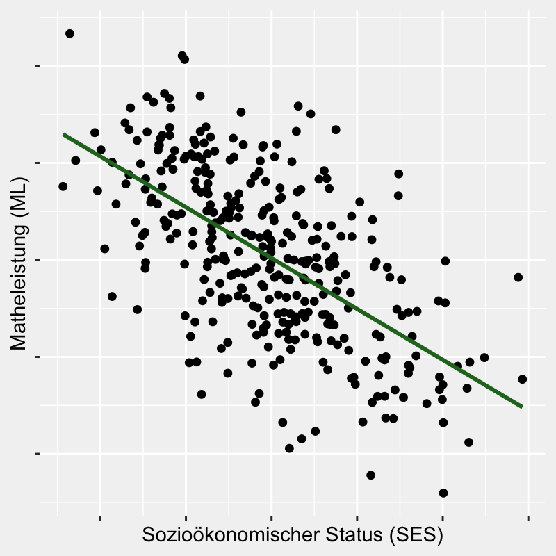

Geben Sie in folgender Tabelle die vier Felder des Binomial Effect Size Display als Werte jeweils zwischen 0 und 1 an.

|  | unterdurchschn. SES | überdurchschn. SES |
| --- | --- | --- |
| überdurchschn. ML |  |  |
| unterdurchschn. ML |  |  |

### 5.2 Lösung:

Die auf zwei Nachkommastellen gerundeten wahren Zahlen sind:

|  | unterdurchschn. SES | überdurchschn. SES |
| --- | --- | --- |
| überdurchschn. ML | 0.81 | 0.19 |
| unterdurchschn. ML | 0.19 | 0.81 |

> ALs »korrekt« wird alles gekennezichent, was ±20% genau ist.

### Übung

Im folgenden ist die einfache lineare Regression von *N* = 329 Datenpunkten der Variable Sozioökonomischer Status (SES) auf die Variable Matheleistung (ML) dargestellt.

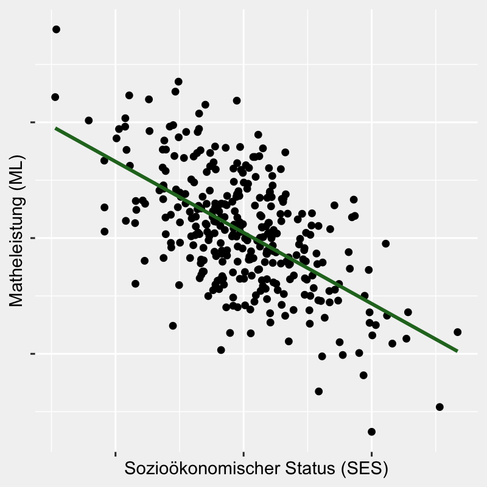

Geben Sie in folgender Tabelle die vier Felder des Binomial Effect Size Display als Werte jeweils zwischen 0 und 1 an.

|  | unterdurchschn. SES | überdurchschn. SES |
| --- | --- | --- |
| überdurchschn. ML |  |  |
| unterdurchschn. ML |  |  |

### 5.3 Lösung:

Die auf zwei Nachkommastellen gerundeten wahren Zahlen sind:

|  | unterdurchschn. SES | überdurchschn. SES |
| --- | --- | --- |
| überdurchschn. ML | 0.8 | 0.2 |
| unterdurchschn. ML | 0.2 | 0.8 |

> ALs »korrekt« wird alles gekennezichent, was ±20% genau ist.

### Übung

Im folgenden ist die einfache lineare Regression von *N* = 447 Datenpunkten der Variable Sozioökonomischer Status (SES) auf die Variable Matheleistung (ML) dargestellt.

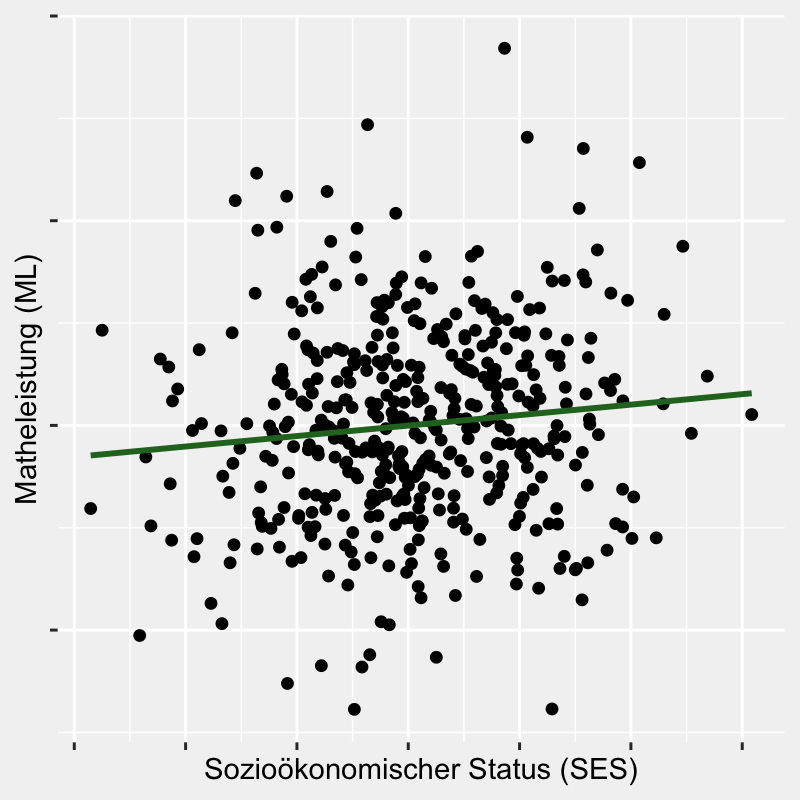

Geben Sie in folgender Tabelle die vier Felder des Binomial Effect Size Display als Werte jeweils zwischen 0 und 1 an.

|  | unterdurchschn. SES | überdurchschn. SES |
| --- | --- | --- |
| überdurchschn. ML |  |  |
| unterdurchschn. ML |  |  |

### 5.4 Lösung:

Die auf zwei Nachkommastellen gerundeten wahren Zahlen sind:

|  | unterdurchschn. SES | überdurchschn. SES |
| --- | --- | --- |
| überdurchschn. ML | 0.45 | 0.55 |
| unterdurchschn. ML | 0.55 | 0.45 |

> ALs »korrekt« wird alles gekennezichent, was ±20% genau ist.

### Übung

Im folgenden ist die einfache lineare Regression von *N* = 382 Datenpunkten der Variable Sozioökonomischer Status (SES) auf die Variable Matheleistung (ML) dargestellt.

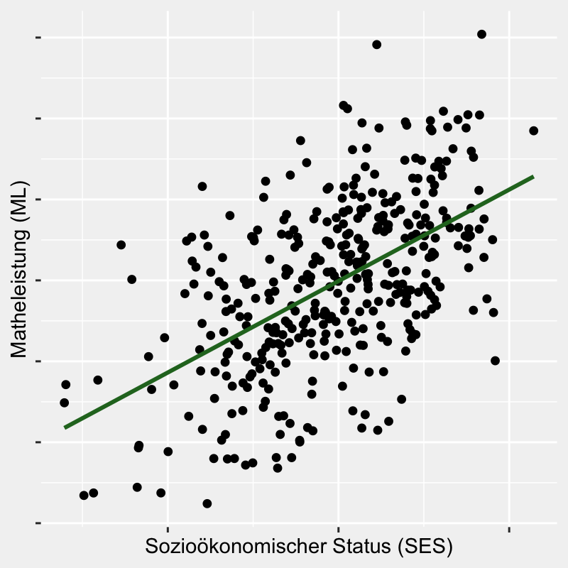

Geben Sie in folgender Tabelle die vier Felder des Binomial Effect Size Display als Werte jeweils zwischen 0 und 1 an.

|  | unterdurchschn. SES | überdurchschn. SES |
| --- | --- | --- |
| überdurchschn. ML |  |  |
| unterdurchschn. ML |  |  |

### 5.5 Lösung:

Die auf zwei Nachkommastellen gerundeten wahren Zahlen sind:

|  | unterdurchschn. SES | überdurchschn. SES |
| --- | --- | --- |
| überdurchschn. ML | 0.23 | 0.77 |
| unterdurchschn. ML | 0.77 | 0.23 |

> ALs »korrekt« wird alles gekennezichent, was ±20% genau ist.

### 5.6 Standardisierte Regressionsgewichte

Ändert man bei einer Regression die Einheiten der abhängigen oder unabhängigen Variable, ändern sich die Regressionsgewichte $b_0$ und $b_1$ ebenfalls, was den Vergleich der Effektgröße über verschiedene Studien hinweg (mit verschiedenen Maßen) schwierig macht (siehe Abbildung 6 links/mitte). Eine Lösung für dieses Problem bietet die sogenannte standardisierte Regression. In dieser z-standardisiert man die abhängige und unabhängige Variable, setzt also deren Mittelwert auf $0$ und die Standardabweichung auf 1.

[figure not shown]

Abbildung 6: Abhängingkeit der Regressionsgewichte $b_0$ und $b_1$ von der Maßeinheit sowie Standardisierte Regression (rechts)

Da die Regressionsgerade immer den »Schwerpunkt der Daten« $\left(\bar{x}, \bar{y}\right) = (\text{Mittelwert UV}, \text{MittelwertAV})$ enthält, entspricht der Achsenabschnitt $\beta_0$ in der standardisierten Regression immer $0$. Die Steigung $\beta_1$ gibt nun an, um wie viele Standardabweichungen sich die abhängige Variable im Durchschnitt in zwei Gruppen unterscheidet, wenn sich die unabhängige Variable um eine Standardabweichung unterscheidet. Das standardisierte Regressionsgewicht $\beta_1$ entspricht dabei exakt der Produkt-Moment-Korrelation (Pearson Korrelation) $r$ zwischen der abhängigen und unabhängigen Variable (siehe Abbildung 6 rechts).

[figure not shown]

Abbildung 7: Dummy-Regression mit standardisierter abhängiger Variable

### 5.7 Der Determinationskoeffizient $R^2$

Der Determinationskoeffizient $R^2$ gibt an, welcher Anteil der Varianz der abhängigen Variable durch die unabhängige Variable erklärt werden kann. Die folgende interaktive Visualisierung demonstriert die folgenden Tatsachen:

1. Der **Mittelwert der abhängigen Variable** $\bar{y}$ ist gleich dem Mittelwert der prädizierten Werte $\bar{\hat{y}}=\bar{y}$.
2. Die **Varianz der abhängigen Variable** $y$ entspricht den mittleren quadrierten Abständen der Punkte zu deren Mittelwert (gestrichelte Linie)
3. Die **Varianz der prädizierte Werte** $\hat{y}$ entspricht den quadrierten Abständen dieser zu deren Mittelwert $\left(\bar{\hat{y}}=\bar{y}= \text{gestrichelte Linie}\right)$
4. Die **Residuen** $\varepsilon$ haben einen Mittelwert von $\bar{\varepsilon}=0$
5. Die mittleren Residuenquadrate sind damit gleich der **Varianz der Residuen**.

In der interaktiven Visualisierung kann man nun beobachten, dass die Summe der **grünen** und **blauen** Flächen immer der gesamten **gelben** Fläche entsprichen. Dies entspricht der Zerlegung der Gesamtvarianz der abhängigen Variable in die durch die Regression erklärte Varianz und die Residualvarianz:

$$\definecolor{primary}{RGB}{38, 115, 38}
\definecolor{secondary}{RGB}{215,125,0}
\definecolor{tertiary}{RGB}{0,120,165}$$

$$\color{secondary}{\text{Var}(y)} \color{black}{=} \color{primary}{\text{Var}(\hat{y})} \color{black}{+} \color{tertiary}{\text{Var}(\varepsilon)} \\$$
In englischen Lehrbüchern werden dafür oft die folgenden Begriffe dafür genutzt,
$$\color{secondary}{\text{Total Sum of Squares}}\color{black} = \color{primary}{\text{Explained Sum of Squares}}+ \color{tertiary}{\text{Residual Sum of Squares}}$$
welche dann wie folgt abgeküzt werden:
$$\color{secondary}{\text{TSS}}= \color{primary}{\text{ESS}} + \color{tertiary}{\text{RSS}}$$

Der Determinationskoeffizient $R^2$ gibt nun an, welcher Anteil der Gesamtvarianz durch die Regression erklärt werden kann:

$$R^2 = \frac{\color{primary}{\text{ESS}}}{\color{secondary}{\text{TSS}}} = 1 - \frac{\color{tertiary}{\text{RSS}}}{\color{secondary}{\text{TSS}}}$$

# R² Visualisierung

Residuenquadrate (RSS) Varianzquadrate (TSS) Erklärte Quadrate (ESS) Fitted Values

[interactive chart not shown]

## Literatur

Fechner, G. T. (1897). *Kollektivmasslehre*. Wilhelm Engelmann.

Rosenthal, R. (2005). Binomial Effect Size Display. In B. S. Everitt & D. C. Howell (Hrsg.), (1. Aufl.). Wiley. Abgerufen von https://onlinelibrary.wiley.com/doi/10.1002/0470013192.bsa050

Word, E. R. (1990). *The state of Tennessee’s student/teacher achievement ratio (STAR) project: Technical report (1985-1990).* (S. 398).